# Módulo 1: Paradigma procedural vs. orientado a objetos

Este notebook é parte do curso de POO para Engenharia de Dados

# Construindo um modelo de Vazão Virtual

Imagine a segiunte tarefa:

- Criar um medidor virtual de vazão, a partir da medição de diferencial de pressão medidor.

```python
import numpy as np

sinal_delta_P = np.random.uniform(low=1000, high=5000, size=100)  # Pa
```

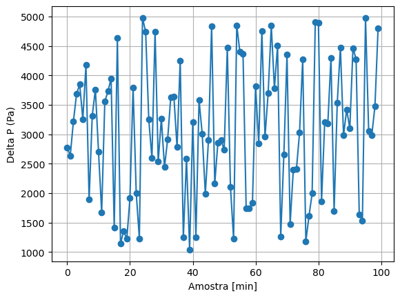

```python
import matplotlib.pyplot as plt

plt.plot(sinal_delta_P, 'o-')
plt.xlabel('Amostra [min]')
plt.ylabel('Delta P (Pa)')
plt.grid()
plt.show()
```

## Modelo de vazão volumétrica simplificado:

Primeiramente, precisamos de um modelo

Aqui, consideremos as seguintes premissas de um modelo do tipo:

onde:

- $C_d$ = coeficiente de descarga (adimensional)
- $Y$ = fator de compressibilidade (adimensional)
- $A$ = área efetiva do orifício (m²)
- $\Delta P$ = diferencial de pressão (Pa)
- $\rho$ = densidade do fluido (kg/m³)

```python
def calcula_vazao_volumetrica(Cd : float, Y: float, A: float, deltaP: float, rho: float) -> float:
    ''' Calcula a vazão mássica através de um orifício

        Parâmetros:
            Cd (float): Coeficiente de descarga (adimensional)
            Y (float): Fator de expansibilidade (adimensional)
            A (float): Área efetiva do orifício (m2)
            deltaP (float): Queda de pressão (Pa)
            rho (float): Densidade do fluido (kg/m3)

        Retornos:
            Q (float): Vazão volumétrica (m3/s)

        Exceções:
            AssertionError: Se Cd <= 0
    '''

    assert Cd > 0, "Cd deve ser maior que zero"

    Q = Cd * Y * (2 * deltaP / rho) ** 0.5

    return Q
```

Observações:

- Padrão docstring é uma convenção para documentar funções, classes e módulos em Python. Acessível via help(função) ou função.**doc**, além de existirme ferramentas como SPhinx que geram documentação mais profissional. Obs.: Nem toda função merece uma documentação completa! Lembresse do KIS"

```python
print(calcula_vazao_volumetrica.__doc__)
```

```
 Calcula a vazão mássica através de um orifício

        Parâmetros:
            Cd (float): Coeficiente de descarga (adimensional)
            Y (float): Fator de expansibilidade (adimensional)
            A (float): Área efetiva do orifício (m2)
            deltaP (float): Queda de pressão (Pa)
            rho (float): Densidade do fluido (kg/m3)

        Retornos:
            Q (float): Vazão volumétrica (m3/s)

        Exceções:
            AssertionError: Se Cd <= 0
```

```python
print(np.random.uniform.__doc__)
```

[output not shown]

[output cut: 34 more lines]

```

        All values are within the given interval:

        >>> np.all(s >= -1)
        True
        >>> np.all(s < 0)
        True

        Display the histogram of the samples, along with the
        probability density function:

        >>> import matplotlib.pyplot as plt
        >>> count, bins, ignored = plt.hist(s, 15, density=True)
        >>> plt.plot(bins, np.ones_like(bins), linewidth=2, color='r')
        >>> plt.show()
```

- Os Type Hints foram introduzidos no Python 3.5 (PEP 484) e são considerados uma boa prática em código Python moderno, especialmente em projetos maiores.

```python
calcula_vazao_volumetrica.__annotations__
```

```
{'Cd': float,
 'Y': float,
 'A': float,
 'deltaP': float,
 'rho': float,
 'return': float}
```

```python
try:
    calcula_vazao_volumetrica(1,1,1,'5',1)
except Exception as e:
    print(f"Erro: {e}")
```

```
Erro: unsupported operand type(s) for /: 'str' and 'int'
```

- O assert é uma declaração em Python usada para verificação de condições e depuração.É uma ferramenta de programação defensiva que ajuda a detectar problemas cedo no desenvolvimento.

```python
calcula_vazao_volumetrica.__builtins__
```

[output not shown]

[output cut: 117 more lines]

[output not shown]

```python
try:
    calcula_vazao_volumetrica(-0.5, 1.0, 2000, 0.78, 850)
except Exception as e:
    print(f"Erro: {e}")
```

```
Erro: Cd deve ser maior que zero
```

### Procedural

- Cd = 0.61 # Coeficiente de descarga (adimensional)
- Y = 1.0 # Fator de expansibilidade (adimensional)
- rho = 0.78 # Densidade do fluido (kg/m3) - típica de metano a 25°C e 1 atm

### Paradigma procedural vs. orientado a objetos

- O paradigma procedural organiza o código em funções e procedimentos, com dados e lógica separados.
- O paradigma orientado a objetos organiza o código em "objetos", que agrupam dados e comportamentos relacionados.

#### Vantagens práticas do paradigma orientado a objetos:

- Facilita a manutenção e evolução do código.
- Permite reutilização e extensão de funcionalidades.
- Torna o código mais próximo do mundo real, facilitando o entendimento.

#### Implicações nas nossas atividades:

- Projetos maiores e mais complexos se beneficiam da organização OO.
- Pequenos scripts podem ser mais simples no procedural, mas OO traz vantagens à medida que o projeto cresce.

#### Exemplo ilustrativo: Equação de estado dos gases ideais

[figure not shown]

```python
# Paradigma Procedural: exemplo prático

# Cálculo do volume molar usando a equação de estado dos gases ideais
R = 0.0821  # constante dos gases (L.atm)/(mol.K)
T = 300     # temperatura (K)
P = 10      # pressão (atm)

# Procedimento procedural

def calc_volume_molar_ideal(T, P):
    return R * T / P

Vm = calc_volume_molar_ideal(T, P)

print(f"Volume molar (procedural): {Vm:.2f} L/mol")

#slideshow: {"slide_type": "slide"}
```

```
Volume molar (procedural): 2.46 L/mol
```

## Discussão prática

- O procedural é direto, mas difícil de expandir para outros tipos de gases ou equações.
- O orientado a objetos permite criar novos métodos e reutilizar o código facilmente.

### Perguntas para reflexão

- Em que situações o procedural é suficiente?
- Quando vale a pena usar OO?
- Como a organização do código impacta a manutenção e evolução dos projetos?

```python
# Paradigma Orientado a Objetos: exemplo prático

class GasIdeal:
    def __init__(self, R=0.0821):
        self.R = R
    def calc_volume_molar(self, T, P):
        return self.R * T / P

gas = GasIdeal()

Vm_oo = gas.calc_volume_molar(T, P)

print(f"Volume molar (orientado a objetos): {Vm_oo:.2f} L/mol")

#slideshow: {"slide_type": "slide"}
```

[output not shown]

## Exemplo prático: Sensor virtual de vazão de gás

Imagine que precisamos criar um sensor virtual para estimar a vazão de um gás em diferentes condições de operação. Com orientação a objetos, podemos criar uma classe que representa o sensor e encapsula toda a lógica necessária, facilitando a manutenção e expansão do código.

```python
# Classe para sensor virtual de vazão de gás

class SensorVirtualVazao:
    def __init__(self, R=0.0821):
        self.R = R
    def calc_volume_molar(self, T, P):
        return self.R * T / P
    def estimar_vazao(self, T, P, n, dt):
        Vm = self.calc_volume_molar(T, P)
        return n * Vm / dt  # vazão em L/s



# Exemplo de uso:

sensor = SensorVirtualVazao()

T = 320  # K

P = 8    # atm

n = 0.5  # mols de gás

dt = 10  # intervalo de tempo em segundos



vazao = sensor.estimar_vazao(T, P, n, dt)

print(f"Vazão estimada: {vazao:.2f} L/s")
```

[output not shown]